# Collision

Jackson Ohanian

2/3/2021

# Regression

This project aims to explore the best metric of state fatal accident data as a means for predicting profitability of car insurance practices.

Profitability is defined as the dollar($USD) amount difference between the losses incurred as a result of collisions (and only collisions) and the average premium paid. This does not consider tax rates, regulatory fees, other streams of income besides premiums, or other causes of loss aside from collision (theft, company overhead, etc.).

The profitability is therefore the variable profit of insuring an additional car per state. An overview of the data (source: FiveThirtyEight - https://github.com/fivethirtyeight/data/tree/master/bad-drivers) is below.

```r
data <- read.csv("538-data.csv")
colnames(data) <- c("state", "fatal.pbm", "was.speeding", "was.dui", "wasnt.distract", "no.prev", "premiums", "ins.losses")
## add state abbreviations using Rs State dataset
data$abbv <- append(append(state.abb[1:8], ("DC")), state.abb[9:50])
head(data)
```

```
##        state fatal.pbm was.speeding was.dui wasnt.distract no.prev premiums
## 1    Alabama      18.8           39      30             96      80   784.55
## 2     Alaska      18.1           41      25             90      94  1053.48
## 3    Arizona      18.6           35      28             84      96   899.47
## 4   Arkansas      22.4           18      26             94      95   827.34
## 5 California      12.0           35      28             91      89   878.41
## 6   Colorado      13.6           37      28             79      95   835.50
##   ins.losses abbv
## 1     145.08   AL
## 2     133.93   AK
## 3     110.35   AZ
## 4     142.39   AR
## 5     165.63   CA
## 6     139.91   CO
```

Consider the new column, the average profit (as defined) in premiums per customer - and given summary statistics.

```r
data <- data %>% mutate(profit = premiums - ins.losses)
data <- data %>% mutate(rel.profit = premiums/ins.losses)
print(data$rel.profit)
```

```
##  [1] 5.407706 7.865900 8.151065 5.810380 5.303447 5.971696 6.398815 7.511685
##  [9] 9.363396 8.046400 6.394608 7.121899 7.757825 5.771542 6.522769 5.670132
## [17] 5.832960 6.362649 6.579474 6.853888 5.442553 7.455135 7.294168 5.828121
## [25] 5.752520 5.471236 9.585555 6.377635 7.424627 6.210299 8.142133 7.203727
## [33] 8.228185 5.540917 6.277342 5.225659 4.928492 7.692477 5.888405 7.733140
## [41] 7.386448 6.909363 4.936106 6.406619 7.392948 6.534075 5.002277 7.973750
## [49] 6.506358 6.286907 6.482629
```

```r
mean(data$profit)
```

```
## [1] 752.4645
```

```r
sd(data$profit)
```

```
## [1] 163.9752
```

Visualization of the profit margin and relative amount between premium and payout per driver -

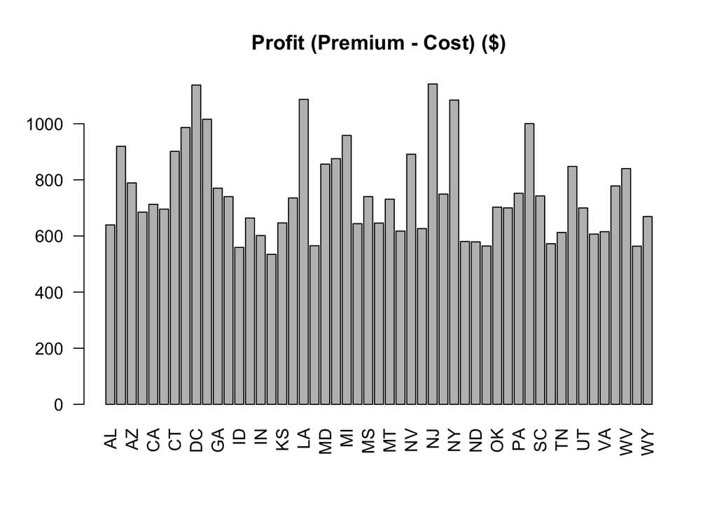

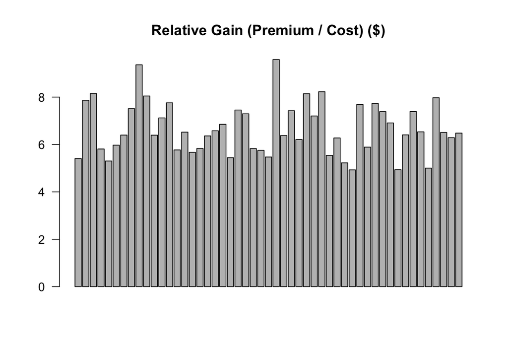

```r
barplot(data$profit, names.arg=data$abbv, las=2, main = 'Profit (Premium - Cost) ($)')
barplot(data$rel.profit, names.arg=text(data$abbv, cex=0.5), las=2, main = 'Relative Gain (Premium / Cost) ($)', cex.arg=0.1)
```

Considering all relevant columns as an effect on lower profit - using AIC step to find the best predictors to model with - and using Leave-one-out Cross-Validation (LOOCV) as a method for finding the best polynomial available for said predictors.

```r
### build initial model
data.glm <- glm(profit ~ fatal.pbm + was.speeding + was.dui + wasnt.distract + no.prev, data = data)
final.bw.step <- step(data.glm, direction = "backward")
```

```
## Start:  AIC=674.95
## profit ~ fatal.pbm + was.speeding + was.dui + wasnt.distract +
##     no.prev
##
##                  Df Deviance    AIC
## - was.speeding    1  1269931 672.99
## - wasnt.distract  1  1271538 673.05
## - was.dui         1  1271806 673.06
## - no.prev         1  1279258 673.36
## <none>               1269031 674.95
## - fatal.pbm       1  1330693 675.37
##
## Step:  AIC=672.99
## profit ~ fatal.pbm + was.dui + wasnt.distract + no.prev
##
##                  Df Deviance    AIC
## - wasnt.distract  1  1272964 671.11
## - was.dui         1  1274217 671.16
## - no.prev         1  1281073 671.43
## <none>               1269931 672.99
## - fatal.pbm       1  1333656 673.48
##
## Step:  AIC=671.11
## profit ~ fatal.pbm + was.dui + no.prev
##
##             Df Deviance    AIC
## - was.dui    1  1277205 669.28
## - no.prev    1  1282339 669.48
## <none>          1272964 671.11
## - fatal.pbm  1  1336483 671.59
##
## Step:  AIC=669.28
## profit ~ fatal.pbm + no.prev
##
##             Df Deviance    AIC
## - no.prev    1  1284149 667.55
## <none>          1277205 669.28
## - fatal.pbm  1  1336700 669.60
##
## Step:  AIC=667.55
## profit ~ fatal.pbm
##
##             Df Deviance    AIC
## <none>          1284149 667.55
## - fatal.pbm  1  1344394 667.89
```

```r
final.fw.step <- step(data.glm, direction = "forward")
```

```
## Start:  AIC=674.95
## profit ~ fatal.pbm + was.speeding + was.dui + wasnt.distract +
##     no.prev
```

```r
final.both.step <- step(data.glm, direction = "both")
```

```
## Start:  AIC=674.95
## profit ~ fatal.pbm + was.speeding + was.dui + wasnt.distract +
##     no.prev
##
##                  Df Deviance    AIC
## - was.speeding    1  1269931 672.99
## - wasnt.distract  1  1271538 673.05
## - was.dui         1  1271806 673.06
## - no.prev         1  1279258 673.36
## <none>               1269031 674.95
## - fatal.pbm       1  1330693 675.37
##
## Step:  AIC=672.99
## profit ~ fatal.pbm + was.dui + wasnt.distract + no.prev
##
##                  Df Deviance    AIC
## - wasnt.distract  1  1272964 671.11
## - was.dui         1  1274217 671.16
## - no.prev         1  1281073 671.43
## <none>               1269931 672.99
## - fatal.pbm       1  1333656 673.48
## + was.speeding    1  1269031 674.95
##
## Step:  AIC=671.11
## profit ~ fatal.pbm + was.dui + no.prev
##
##                  Df Deviance    AIC
## - was.dui         1  1277205 669.28
## - no.prev         1  1282339 669.48
## <none>               1272964 671.11
## - fatal.pbm       1  1336483 671.59
## + wasnt.distract  1  1269931 672.99
## + was.speeding    1  1271538 673.05
##
## Step:  AIC=669.28
## profit ~ fatal.pbm + no.prev
##
##                  Df Deviance    AIC
## - no.prev         1  1284149 667.55
## <none>               1277205 669.28
## - fatal.pbm       1  1336700 669.60
## + was.dui         1  1272964 671.11
## + was.speeding    1  1274052 671.15
## + wasnt.distract  1  1274217 671.16
##
## Step:  AIC=667.55
## profit ~ fatal.pbm
##
##                  Df Deviance    AIC
## <none>               1284149 667.55
## - fatal.pbm       1  1344394 667.89
## + no.prev         1  1277205 669.28
## + was.speeding    1  1280868 669.42
## + was.dui         1  1282339 669.48
## + wasnt.distract  1  1282753 669.50
```

```r
final.bw.step
```

```
##
## Call:  glm(formula = profit ~ fatal.pbm, data = data)
##
## Coefficients:
## (Intercept)    fatal.pbm
##     885.435       -8.421
##
## Degrees of Freedom: 50 Total (i.e. Null);  49 Residual
## Null Deviance:       1344000
## Residual Deviance: 1284000   AIC: 667.6
```

```r
final.fw.step
```

```
##
## Call:  glm(formula = profit ~ fatal.pbm + was.speeding + was.dui + wasnt.distract +
##     no.prev, data = data)
##
## Coefficients:
##    (Intercept)       fatal.pbm    was.speeding         was.dui  wasnt.distract
##       591.6789         -8.7405          0.4689          1.6107          0.4815
##        no.prev
##         2.1766
##
## Degrees of Freedom: 50 Total (i.e. Null);  45 Residual
## Null Deviance:       1344000
## Residual Deviance: 1269000   AIC: 675
```

```r
final.both.step
```

```
##
## Call:  glm(formula = profit ~ fatal.pbm, data = data)
##
## Coefficients:
## (Intercept)    fatal.pbm
##     885.435       -8.421
##
## Degrees of Freedom: 50 Total (i.e. Null);  49 Residual
## Null Deviance:       1344000
## Residual Deviance: 1284000   AIC: 667.6
```

```r
### MSE
cv.mse.bw <- cv.glm(data, final.bw.step)
cv.mse.fw <- cv.glm(data, final.fw.step)
cv.mse.both <- cv.glm(data, final.both.step)

### LOOCV
## for each of the found models - consider polynomial modifications to each of the AIC step models
## Backward and both are only fatalities per billion miles
## forward is all predictors
cv.mse.bw = rep(-1,5)
cv.mse.fw = rep(-1,5)

for (i in 1:5)
{
  data.loocv.bw <- glm(profit ~ poly(fatal.pbm, i), data = data)
  data.loocv.fw <- glm(profit ~ poly(fatal.pbm, i) +  was.speeding + poly(was.dui, i) + wasnt.distract + no.prev, data = data)

  cv.mse.bw[i] = cv.glm(data, data.loocv.bw)$delta[1]
  cv.mse.fw[i] = cv.glm(data, data.loocv.fw)$delta[1]
}

cv.mse.bw
```

```
## [1] 27499.61 25937.46 24975.26 30623.77 53213.69
```

```r
### select polynomial - 3
bw.poly <- 3
cv.mse.fw
```

```
## [1]  31666.68  29681.47  30557.98  96110.73 199672.42
```

```r
### select polynomial - 2
fw.poly <- 2

### New Models
model.bw <- glm(profit ~ poly(fatal.pbm, bw.poly), data = data)
model.fw <- glm(profit ~ poly(fatal.pbm, fw.poly) +  was.speeding + poly(was.dui, fw.poly) + wasnt.distract + no.prev, data = data)

summary(model.bw)
```

```
##
## Call:
## glm(formula = profit ~ poly(fatal.pbm, bw.poly), data = data)
##
## Deviance Residuals:
##     Min       1Q   Median       3Q      Max
## -199.34  -119.50   -37.05    78.59   365.93
##
## Coefficients:
##                           Estimate Std. Error t value Pr(>|t|)
## (Intercept)                 752.46      21.66  34.745   <2e-16 ***
## poly(fatal.pbm, bw.poly)1  -245.45     154.66  -1.587   0.1192
## poly(fatal.pbm, bw.poly)2   335.26     154.66   2.168   0.0353 *
## poly(fatal.pbm, bw.poly)3  -218.03     154.66  -1.410   0.1652
## ---
## Signif. codes:  0 '***' 0.001 '**' 0.01 '*' 0.05 '.' 0.1 ' ' 1
##
## (Dispersion parameter for gaussian family taken to be 23919.44)
##
##     Null deviance: 1344394  on 50  degrees of freedom
## Residual deviance: 1124214  on 47  degrees of freedom
## AIC: 664.77
##
## Number of Fisher Scoring iterations: 2
```